# Home

Welcome to our wedding website! Here you can find all the information you need about the wedding as and when it becomes available.

We know how important logistics are to any wedding and we want to make sure that we make it as hassle free as possible. We've included information on transport, accommodation, the location of the wedding ceremony, catering, dress code, bridal registry and a little bit about our story as a couple.

Our wedding doesn't have a theme but we are aiming to make it as sustainable as possible. We will be using eco-friendly decorations, our catering will be vegetarian and vegan and we will not have cut flowers.

We will be sending out Google forms shortly on accommodation and catering.

# Logistics

We will be able to confirm our finalised schedule very soon!

# Transport

## Flights

> London City Airport is two stops away from Woolwich Arsenal where we live. We suggest that if you will be landing Friday 9th August and coming to Woolwich, that you try to use this airport as it's small and easy to get to us after you land. To leave to go to the airport from Hoath House, we suggest you opt for a return flight from Gatwick airport.

> London Gatwich is close to Hoath House, therefore if you are going straight to your accommodation on Friday night, we suggest you fly into this airport.

> London Heathrow is 3 hours from Hoath House by public transport and 2 hours from Woolwich. It's not the best option but for international flights you may find it's your best option for a direct flight (you would then gain tiem during your travel and just need to account for extra travel time when you land). However, you are also free to stay somewhere else in London on the Friday night and join us at Hoath House on Saturday afternoon (exact timings to be confirmed)

## Private coach

We will be providing a private coach from: - Woolwich to the wedding venue - from the wedding venue to London on Monday 12th August

## Taxis

- We will be providing taxis on call on Saturday 10th August in the evening to take guests from the wedding venue to their accommodation.
- For travel from your hotel to the wedding venue on Sunday, and for departure to a local train station, we have a litst of recommended taxi companies below.

Taxi companies:

> Tonbridge  
> Taxis  
> Tonbridge  
> 01732 773300

> Streamline  
> Kent  
> 01732 505050

> Reylon Cars  
> Edenbridge  
> 01732 863800

> Hilden Cars  
> Hildenbrough  
> 07535 123321

> Castle Cars  
> Tonbridge  
> 01732 363637

# Accomodation

## Woolwich, London (Aug 9)

> Premer Inn London Woolwich (Royal Arsenal) Hotel  
> Address: 91 Beresford St, Woolwich, London SE18 6BG  
> Phone: 0871 097 1087

> Travelodge London Woolwich  
> Address: 129 Powis St, Woolwich,London SE18 6LQ  
> Phone: 0871 984 6510

There are also some great Air BnB options in Woolwich Arsenal, the residential complex we live in: https://www.airbnb.co.uk/s/Woolwich--Greater-London--United-Kingdom/homes?refinement_paths%5B%5D=%2Fhomes&adults=2&children=0&checkin=2019-08-09&checkout=2019-08-10&allow_override%5B%5D=&zoom=15&search_by_map=true&sw_lat=51.4849939726893&sw_lng=0.05779944015314132&ne_lat=51.49787156523216&ne_lng=0.08488709427063267&search_type=UNKNOWN&s_tag=WEVRquBj

## Countryside (Aug 10/11)

#### Bed & Breakfast

The following has been recommended by the Wedding Venue owners:

> Mill Hill  
> Edenbridge, Kent, TN8 5DA,  
> 01732 866781

> Anne Gilbert  
> Chiddingstone Village  
> 01892 870663

> Jacqui Wilcox  
> Becketts, Cowden  
> 01342 850514  
> www.becketts-bandb.co.uk

> Nicholas & Ginny Morris 3  
> Charcott Farmhouse, Charcott, Leigh TN11 8LG  
> 01892 870024  
> charcottfarmhouse@btinternet.com  
> www.smoothhound.co.uk/hotels/charcott

> Sara Hills  
> Brownings Farmhouse, Chiddingstone  
> 01732 464635  
> Brownings Farmhouse, Hale Oak Road, Chiddingstone, Kent, TN8 7AX

> Sarah Byrne  
> Whitepost Oast, Chiddingstone Causeway  
> 01892 870058

> Southernwood House  
> Church Street, Hever, Kent, TN8 7JE  
> 01342 850880

#### Pubs and Hotels

> The Greyhound Pub  
> Hever  
> 01732 862221 www.greyhoundhever.co.uk

> The Royal Oak Hotel  
> Sevenoaks  
> 01732 451109  
> www.brook-hotels.co.uk

> Starborough Manor  
> Marsh Green Road, Marsh Green  
> Edenbridge, Kent, TN8 5QY  
> 01732 862152

#### Cottage only (no meals provided)

> Garden of England Cottages, many within easy reach of Chiddingstone.  
> Kent and Sussex  
> 01892 510117  
> www.gardenofenglandcottages.co.uk

> Watstock Barns  
> Chiddingstone Hoath  
> 01892 870701  
> www.watstockbarns.co.uk

# Location

> Hoath House  
> Chiddingstone Hoath  
> Edenbridge TN8 7DB

We will be getting married at Hoath House in the afternoon of August 10th, following our civil ceremony with immediate family and witnesses the morning of August 10th.

The house is situated on the rolling hills of the Kent countryside and belongs to the Streatfields, a historic family from Chiddingstone which goes back to the 16th century.They were significant landowners in Sussex, Surrey and Kent, and instrumental in shaping those counties throughout the 17th and 18th centuries.The family lived at Chiddingstone Castle for 400 years until 1910 when they sold their castle and Sir Henry Streatfeild moved to Hoath House.

It was originally a Tudor farm and now boasts beautiful gardens. Colonel Sir Henry created a formal ornamental garden when he moved to the house in 1910, much of which still survives.

https://hoathhouse.com/

# Catering

As you have no doubt noticed, we are only offering vegetarian or vegan options. This decision has been received to mixed reviews ???. We would like to explain very quickly why we believe that vegetarianism is important.

https://ourworldindata.org/meat-and-seafood-production-consumption The world's "poor" are getting less poor. As they get less poor, they want to eat more meat (because that's what rich people do and that's what they wanted to do when they were poor). As the demand for meat increases, so does the demand for its feed, mainly soybean. This creates a situation where farmers that used to grow other food now grow soybean for export because it makes the most money. This means the price of the stuff they USED to grow goes up (because production goes down), making food for humans more expensive. This also creates a double-danger. not only is population increasing, but each person's meat consumption is also increasing, a wonderful double-punch. Everyone who studies this phenomenon has said that this will create problems in the future.

Everyone attending this wedding is the global elite. Regardless of your religious, ethical, or moral convictions, we should be dispelling the myth that rich people eat meat every day because it's the right thing for our planet.

# Dress code

We don't have a theme for our wedding and the dress code is casual. If you're not sure what this includes, having looked up what this means in wedding terms, some suggestions include a summer dress for women, a shirt and dress pants for men but we're hippies and we accept you whatever you decide to wear!

Practically speaking, we will be outside for the ceremony and reception, therefore worth having an extra layer somewhere just in case and planning for shoes that you can wear in the gardens (thin heels might be tricky). We are aiming to be as sustainable as possible and therefore would never ask you to buy something especially for the wedding that you may not wear again.

If you do want to buy something and are interested in being sustainable, you have two options: buying something second hand or going for an ethical brand.

"Ethical consumer" explains what to look out for when shopping for clothes (chemicals used in production, fabric used, labour practices) and gives a rating to regular high street brands. https://www.ethicalconsumer.org/fashion-clothing/shopping-guide/clothes-shops "Good on you" is a great website for ethical brands https://goodonyou.eco/

# Bridal registry

We don't have one! Neither of us likes accumulating material things and are more interested in having great experiences surrounded by the people we love.

If you would still like to contribute something, we are happy to accept contributions to our honeymoon in Sicily!

However, please do NOT feel obliged to do this, you are already dedicating time, money and energy to be with us on our special day.

# Our Story

We met in Rome in 2011, but as often happens in life, it was difficult to see the true value of people in a crowd. It wasn’t until Laure left Rome and posted this picture on Facebook in January 2013 that the universe began to conspire:

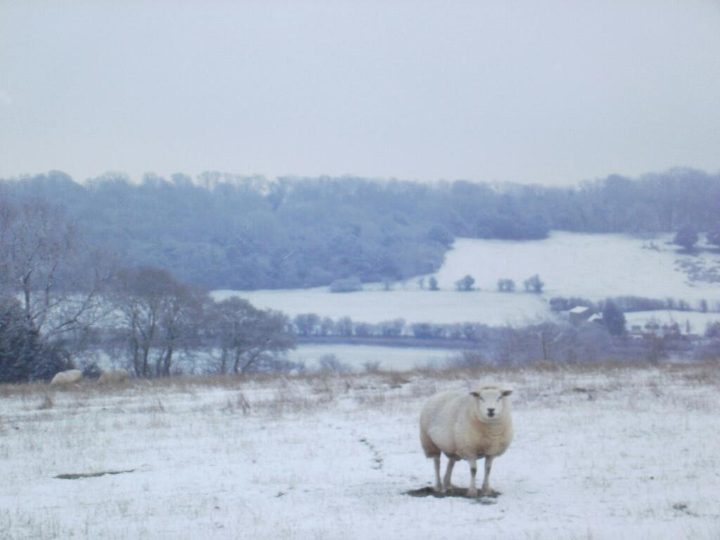

Which started an excellent conversation that went something like this: Amit: Where are you? Laure: I'm in Waltham in the UK Amit: when r you back? Laure: I'm working for a university here… I may visit Rome again in a few months though. Amit: Oh... I didn't know you had LEFT LEFT.... or maybe I knew and forgot! Bummer! Why'd you leave for? (this is verbatim… Amit has always been so eloquent). … Anyway, long story short, this started off a conversation that started on Facebook Messenger and then moved over to emails. Long emails. They spoke about everything, the emails included everything from humor to health issues, to interesting discussion topics, etc. The emails became longer and longer, and were always highly anticipated. It was here that the first brick of a sustainable relationship was established: a mutual genuine interest in what the other person had to say. This is important for two reasons: 1) it demonstrated an intellectual compatibility, and 2) the values of both started to be demonstrated. This is the birthplace of respect.

# Our song

Laure has played the piano since she was seven years old and by sheer coincidence, some of her favourite pieces are ones that Amit loves to hear. It became part of our weekends to have some piano playing going on with Amit listening in the background. She had also written a few short pieces in the past but it had been a while… One morning in Accra, she had the idea to compose a piece for their second-year anniversary and after a few days of thinking about the concept behind the piece, it came to her as she woke up. She knew it should sound "fragile" at first, as that was how their relationship started. At the start of the piece, the right and left hand are further apart and sound a bit out of sync, to symbolize some of the doubt they felt about each other.  
The same theme repeats with the right and left hand closer this time, to symbolize how their core feelings towards each other were there from the very beginning but needed time and space to be nurtured. At the end of the second line (6 months into our relationship), we realized we were in love! We declared our love to each other and then began a steady period of starting to live together, creating a little "nest" of music, creative projects and little routines on the weekends like their Saturday brunch and frequent visit to the organic food market. The left and right then become more in sync with each other as the song progresses until a final section in which we have become confident and secure as a couple. The piece ends peacefully.

RSVP

Please complete the RSVP here: http://bit.ly/Laure_Amit